# Performance Metrics in Classification Problem

#### Dina Machuve

18th April, 2020

#### Outline

- Binary Classifier example
- Confusion Matrix
- ROC
- AUC

#### Binary Classifier example

**Task**: Can we predict a digit `8` from the [MNIST](https://en.wikipedia.org/wiki/MNIST_database) dataset of handwritten digits?

- We have a basic "binary" classification problem
- 1 = the digit is 8 and 0 = the digit is not-8
- Dataset of 70,000 images of handwritten digits
- Training with a *Stochastic Gradient Descent (SGD)* classifier

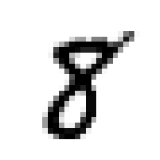

```python
#check one digit
some_digit = X[39005]
some_digit_image = some_digit.reshape(28,28)

plt.imshow(some_digit_image, cmap=matplotlib.cm.binary, interpolation="nearest")
plt.axis("off")
plt.show()
```

```python
#check the label
y[39005]
```

```
'8'
```

#### Confusion Matrix

Used to evaluate the performance of a classifier using a set of predictions compared to the actual target.

$$Confusion \ matrix = actual \left\{\overbrace{ \begin{bmatrix} neg. & \overbrace{TN}^{negative} & \overbrace{FP}^{positive} \\ pos. & FN & TP \end{bmatrix}}^{predicted} \right.$$

- Each **row** in a confusion matrix represents an **actual class**
- Each **column** represents a **predicted class**
- True Positive (TP): The cases in which the model predicted "yes/positive", and the truth is also “yes/positive."
- True Negatives (TN): The cases in which the model predicted "no/negative", and the truth is also "no/negative."
- False Positives (FP): The cases in which the model predicted "yes/positive", and the truth is "no/negative".
- False Negatives (FN): The cases in which the model predicted "no/negative", and the truth is "yes/positive".

```python
#To compute the confusion matrix
#1. we need a set of predictions to be compared to the actual targets
from sklearn.model_selection import cross_val_predict
y_train_pred = cross_val_predict(sgd_clf, X_train, y_train_8, cv=3)

from sklearn.metrics import confusion_matrix
confusion_matrix(y_train_8, y_train_pred)
```

```
array([[49130,  5019],
       [ 1308,  4543]])
```

#### Using information from the confusion matrix

$confusion \ matrix = \begin{bmatrix} TN & FP \\ FN & TP \end{bmatrix} \quad = \quad \begin{bmatrix} 49130 & 5019 \\ 1308 & 4543 \end{bmatrix}$

- Number of samples:

$n = TP + TN + FP + FN \\ = 4543 + 49130 + 5019 + 1308 \\ = 60000$

- **Accuracy**: In general how often is the classifier correct? $\Rightarrow \frac{(TP + TN)}{n} \\ = \frac{(4543 + 49130)}{60000} = 0.89455$
- **Misclassification Rate (Error Rate)**: How often is the model wrong? $\Rightarrow \frac{(FP + FN)}{n} \\ =\frac{(5019 + 1308)}{60000} = 0.10545$
- **Precision**: When the model predicts "yes", how often is it correct?

$$ \begin{align*} \mathbf{Precision} =& \frac{TP}{(TP + FP)} \\ =& \frac{4543}{(4543 + 5019)} \\ =& 0.47511 \end{align*} $$

- **Recall (True Positive Rate)**: How often the model predicts yes, when it's "actually yes"

$$ \begin{align*} \mathbf{Recall} =& \frac{TP}{(TP + FN)} \\ =& \frac{4543}{(4543 + 1308)} \\ =& 0.77645 \end{align*} $$

```python
#precision
from sklearn.metrics import precision_score, recall_score
precision_score(y_train_8, y_train_pred)
```

```
0.4751098096632504
```

```python
#recall
recall_score(y_train_8, y_train_pred)
```

```
0.7764484703469492
```

#### Receiver Operating Characteristics (ROC)

ROC is a visual way to inspect the performance of a binary classifier

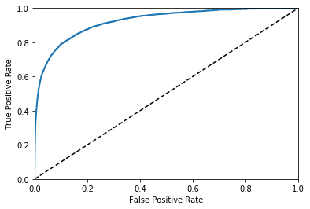

```python
from sklearn.metrics import roc_curve
fpr, tpr, thresholds = roc_curve(y_train_8, y_scores)
#plot the FPR again the TPR
def plot_roc_curve(fpr, tpr, label=None):
    plt.plot(fpr, tpr, linewidth=2, label=label)
    plt.plot([0,1], [0,1], 'k--')
    plt.axis([0,1,0,1])
    plt.xlabel("False Positive Rate")
    plt.ylabel("True Positive Rate")

plot_roc_curve(fpr,tpr)
plt.show()
```

#### Area Under the Curve (AUC)

There is one more concept we should know:

- Area under the curve or AUC, is the amount of space underneath the ROC curve.
- AUC shows how well the TPR and FPR is looking in the aggregate.
- The greater the area under the curve, shows the higher quality of the model.
- The greater the area under the curve, the higher the ratio of true positives to false positives as the threshold becomes more lenient
- $ AUC = 0 \Rightarrow BAD$
- $ AUC = 1 \Rightarrow GOOD$

```python
from sklearn.metrics import roc_auc_score
roc_auc_score(y_train_8, y_scores)
```

```
0.9235163800533808
```

#### References

1. Lecture 3.1 Linear Regression, [Delta Analytics](http://www.deltanalytics.org/)
2. Aurélien Géron (2017), Chapter 3 Classification, [Hands-on Machine Learning with Scikit-Learn and TensorFlow](https://learning.oreilly.com/library/view/hands-on-machine-learning/9781491962282/)